# ✈️ Projet Data Science — Retards de vols US

# 3. Compréhension du dataset

Explorez rapidement les colonnes et les valeurs manquantes.

Questions :

- Quelles colonnes semblent utiles pour analyser les retards ?
- Quelles colonnes sont disponibles avant le vol ?
- Quelles colonnes sont connues seulement après le vol ?
- Quelles colonnes peuvent créer du data leakage ?

```python
df.info(show_counts=True)
print("\n--- Taux de valeurs manquantes (>0) ---")
missing = df.isna().mean().mul(100).round(2).sort_values(ascending=False)
print(missing[missing > 0].to_string())
```

```
<class 'pandas.DataFrame'>
RangeIndex: 5819079 entries, 0 to 5819078
Data columns (total 31 columns):
 #   Column               Non-Null Count    Dtype
---  ------               --------------    -----
 0   YEAR                 5819079 non-null  int16
 1   MONTH                5819079 non-null  int8
 2   DAY                  5819079 non-null  int8
 3   DAY_OF_WEEK          5819079 non-null  int8
 4   AIRLINE              5819079 non-null  category
 5   FLIGHT_NUMBER        5819079 non-null  int64
 6   TAIL_NUMBER          5804358 non-null  str
 7   ORIGIN_AIRPORT       5819079 non-null  category
 8   DESTINATION_AIRPORT  5819079 non-null  category
 9   SCHEDULED_DEPARTURE  5819079 non-null  int16
 10  DEPARTURE_TIME       5732926 non-null  float64
 11  DEPARTURE_DELAY      5732926 non-null  float64
 12  TAXI_OUT             5730032 non-null  float64
 13  WHEELS_OFF           5730032 non-null  float64
 14  SCHEDULED_TIME       5819073 non-null  float64
 15  ELAPSED_TIME         5714008 non-null  float64
 16  AIR_TIME             5714008 non-null  float64
 17  DISTANCE             5819079 non-null  int32
 18  WHEELS_ON            5726566 non-null  float64
 19  TAXI_IN              5726566 non-null  float64
 20  SCHEDULED_ARRIVAL    5819079 non-null  int64
 21  ARRIVAL_TIME         5726566 non-null  float64
 22  ARRIVAL_DELAY        5714008 non-null  float64
 23  DIVERTED             5819079 non-null  int8
 24  CANCELLED            5819079 non-null  int8
 25  CANCELLATION_REASON  89884 non-null    category
 26  AIR_SYSTEM_DELAY     1063439 non-null  float64
 27  SECURITY_DELAY       1063439 non-null  float64
 28  AIRLINE_DELAY        1063439 non-null  float64
 29  LATE_AIRCRAFT_DELAY  1063439 non-null  float64
 30  WEATHER_DELAY        1063439 non-null  float64
dtypes: category(4), float64(16), int16(2), int32(1), int64(2), int8(5), str(1)
memory usage: 982.9 MB

--- Taux de valeurs manquantes (>0) ---
CANCELLATION_REASON   98.460
WEATHER_DELAY         81.720
LATE_AIRCRAFT_DELAY   81.720
AIRLINE_DELAY         81.720
SECURITY_DELAY        81.720
AIR_SYSTEM_DELAY      81.720
AIR_TIME               1.810
ARRIVAL_DELAY          1.810
ELAPSED_TIME           1.810
WHEELS_ON              1.590
TAXI_IN                1.590
ARRIVAL_TIME           1.590
TAXI_OUT               1.530
WHEELS_OFF             1.530
DEPARTURE_DELAY        1.480
DEPARTURE_TIME         1.480
TAIL_NUMBER            0.250
```

**Réponses aux questions de la section 3 — typologie des colonnes**

| Disponibilité | Colonnes |
| --- | --- |
| **Avant le vol** (potentiellement prédictives) | `YEAR`, `MONTH`, `DAY`, `DAY_OF_WEEK`, `AIRLINE`, `FLIGHT_NUMBER`, `TAIL_NUMBER`, `ORIGIN_AIRPORT`, `DESTINATION_AIRPORT`, `SCHEDULED_DEPARTURE`, `SCHEDULED_ARRIVAL`, `SCHEDULED_TIME`, `DISTANCE` |
| **Après le vol** (à exclure des features) | `DEPARTURE_TIME`, `TAXI_OUT`, `WHEELS_OFF`, `ELAPSED_TIME`, `AIR_TIME`, `WHEELS_ON`, `TAXI_IN`, `ARRIVAL_TIME`, `DIVERTED`, `CANCELLED`, `CANCELLATION_REASON` |
| **Cible / leakage direct** | `ARRIVAL_DELAY` (cible), `DEPARTURE_DELAY`, `AIR_SYSTEM_DELAY`, `SECURITY_DELAY`, `AIRLINE_DELAY`, `LATE_AIRCRAFT_DELAY`, `WEATHER_DELAY` |

⚠️ **Data leakage critique** :

- `ARRIVAL_DELAY` est notre cible — on en dérive `IS_DELAYED` à la section 6.
- `DEPARTURE_DELAY` est tentant mais reflète un événement *après* l'heure programmée de départ. On se place avant le vol → on l'exclut des features.
- Les `*_DELAY` décomposés (AIR_SYSTEM, SECURITY, AIRLINE, LATE_AIRCRAFT, WEATHER) sont des post-mortem causaux — uniquement renseignés pour les vols déjà retardés (~80 % de NA).

# 4. Sélection des colonnes utiles

Sélectionnez un sous-ensemble de colonnes pour simplifier le projet.

Colonnes suggérées :

- `YEAR`
- `MONTH`
- `DAY`
- `DAY_OF_WEEK`
- `AIRLINE`
- `ORIGIN_AIRPORT`
- `DESTINATION_AIRPORT`
- `SCHEDULED_DEPARTURE`
- `DEPARTURE_DELAY`
- `SCHEDULED_TIME`
- `DISTANCE`
- `ARRIVAL_DELAY`
- `CANCELLED`
- `DIVERTED`

Question :

- Pourquoi ne pas garder toutes les colonnes ?

```python
cols = [
    "YEAR", "MONTH", "DAY", "DAY_OF_WEEK",
    "AIRLINE", "ORIGIN_AIRPORT", "DESTINATION_AIRPORT",
    "SCHEDULED_DEPARTURE", "SCHEDULED_TIME", "DISTANCE",
    "DEPARTURE_DELAY",   # gardé pour EDA, EXCLU du modèle (data leakage)
    "ARRIVAL_DELAY",     # cible
    "CANCELLED", "DIVERTED",
]
df = df[cols].copy()
print(f"Après sélection : {df.shape[0]:,} × {df.shape[1]} "
      f"({df.memory_usage(deep=True).sum()/1e6:.1f} Mo)")
df.dtypes
```

```
Après sélection : 5,819,079 × 14 (244.5 Mo)
```

```
YEAR                      int16
MONTH                      int8
DAY                        int8
DAY_OF_WEEK                int8
AIRLINE                category
ORIGIN_AIRPORT         category
DESTINATION_AIRPORT    category
SCHEDULED_DEPARTURE       int16
SCHEDULED_TIME          float64
DISTANCE                  int32
DEPARTURE_DELAY         float64
ARRIVAL_DELAY           float64
CANCELLED                  int8
DIVERTED                   int8
dtype: object
```

# 5. Nettoyage des données

Pour cette étude, on s’intéresse aux retards à l’arrivée.

Décisions à prendre :

- Que faire des vols annulés ?
- Que faire des vols déroutés ?
- Que faire des lignes sans `ARRIVAL_DELAY` ?

À justifier dans votre rapport.

```python
n_init = len(df)
n_cancel = int(df["CANCELLED"].sum())
n_div = int(df["DIVERTED"].sum())
# Vols annulés / déroutés : pas d'ARRIVAL_DELAY mesurable, hors-périmètre.
n_nan_arr_no_cancel = int(df.loc[(df["CANCELLED"] == 0) & (df["DIVERTED"] == 0),
                                  "ARRIVAL_DELAY"].isna().sum())

mask_valid = (df["CANCELLED"] == 0) & (df["DIVERTED"] == 0) & df["ARRIVAL_DELAY"].notna()
df = df.loc[mask_valid].drop(columns=["CANCELLED", "DIVERTED"]).copy()

print(f"Initial                : {n_init:,}")
print(f" - vols annulés        : {n_cancel:,} ({n_cancel/n_init*100:.2f} %)")
print(f" - vols déroutés       : {n_div:,} ({n_div/n_init*100:.2f} %)")
print(f" - NA arrival restants : {n_nan_arr_no_cancel:,} (vols ni annulés ni déroutés)")
print(f"Après nettoyage        : {len(df):,} ({len(df)/n_init*100:.1f} % conservés)")

# ---- Correction qualité données : codes aéroports d'octobre ----
# Octobre 2015 utilise parfois des codes BTS L_AIRPORT_ID numériques au lieu de l'IATA.
# Le mapping est fourni dans outputs/bts_to_iata.json lorsque disponible.
mapping_path = OUTPUT_DIR / "bts_to_iata.json"
if mapping_path.exists():
    with mapping_path.open() as f:
        BTS_TO_IATA = json.load(f)

    df["ORIGIN_AIRPORT"] = df["ORIGIN_AIRPORT"].astype(str).map(lambda c: BTS_TO_IATA.get(c, c))
    df["DESTINATION_AIRPORT"] = df["DESTINATION_AIRPORT"].astype(str).map(lambda c: BTS_TO_IATA.get(c, c))
    df["ORIGIN_AIRPORT"] = df["ORIGIN_AIRPORT"].astype("category")
    df["DESTINATION_AIRPORT"] = df["DESTINATION_AIRPORT"].astype("category")

    n_remaining_numeric = df["ORIGIN_AIRPORT"].astype(str).str.isdigit().sum()
    print(f"Codes numériques résiduels post-mapping : {n_remaining_numeric:,} vols "
          f"({n_remaining_numeric/len(df)*100:.3f} %)")
else:
    print("Mapping outputs/bts_to_iata.json absent : correction BTS→IATA ignorée sans bloquer l'exécution.")
```

```
Initial                : 5,819,079
 - vols annulés        : 89,884 (1.54 %)
 - vols déroutés       : 15,187 (0.26 %)
 - NA arrival restants : 0 (vols ni annulés ni déroutés)
Après nettoyage        : 5,714,008 (98.2 % conservés)
Mapping outputs/bts_to_iata.json absent : correction BTS→IATA ignorée sans bloquer l'exécution.
```

# 6. Création de la variable cible

On considère généralement qu’un vol est en retard s’il arrive avec plus de 15 minutes de retard.

Créez une variable :

```
IS_DELAYED = 1 si ARRIVAL_DELAY > 15, sinon 0
```

Question :

- Ce seuil de 15 minutes vous semble-t-il pertinent ?
- Dans quels cas métier pourrait-on choisir un autre seuil ?

```python
THRESHOLD_MIN = 15  # seuil standard FAA pour "vol en retard"
df["IS_DELAYED"] = (df["ARRIVAL_DELAY"] > THRESHOLD_MIN).astype("int8")

rate = df["IS_DELAYED"].mean()
print(f"Seuil retenu              : > {THRESHOLD_MIN} min")
print(f"Taux de vols en retard    : {rate*100:.2f} %")
print(f"Nb vols retardés / total  : {df['IS_DELAYED'].sum():,} / {len(df):,}")
print(f"Déséquilibre de classe    : {(1-rate)/rate:.1f} : 1 (non-retardés : retardés)")
```

```
Seuil retenu              : > 15 min
Taux de vols en retard    : 17.91 %
Nb vols retardés / total  : 1,023,498 / 5,714,008
Déséquilibre de classe    : 4.6 : 1 (non-retardés : retardés)
```

# 7. Feature engineering

Créez quelques variables simples pour l’analyse.

Suggestions :

- heure prévue de départ à partir de `SCHEDULED_DEPARTURE`
- indicateur week-end
- éventuellement période de la journée : matin / après-midi / soir

Attention : les colonnes `ORIGIN_AIRPORT` et `DESTINATION_AIRPORT` peuvent contenir un mélange de nombres et de texte.  
Pour éviter des erreurs plus tard, vous pouvez les convertir en texte.

```python
# Cast en str pour éviter les surprises (certains codes aéroports sont alphanumériques)
for c in ["ORIGIN_AIRPORT", "DESTINATION_AIRPORT", "AIRLINE"]:
    df[c] = df[c].astype(str)

# Heure prévue de départ : SCHEDULED_DEPARTURE est au format HHMM (ex: 1435 -> 14h)
df["SCHEDULED_DEP_HOUR"] = (df["SCHEDULED_DEPARTURE"] // 100).clip(0, 23).astype("int8")

# Période de la journée
def _period(h: int) -> str:
    if h < 6:  return "nuit"
    if h < 12: return "matin"
    if h < 18: return "après-midi"
    return "soir"
df["DEP_PERIOD"] = df["SCHEDULED_DEP_HOUR"].map(_period).astype("category")

# Week-end (samedi=6, dimanche=7 dans ce dataset)
df["IS_WEEKEND"] = (df["DAY_OF_WEEK"] >= 6).astype("int8")

df[["SCHEDULED_DEPARTURE", "SCHEDULED_DEP_HOUR", "DEP_PERIOD",
    "DAY_OF_WEEK", "IS_WEEKEND"]].head()
```

|  | SCHEDULED_DEPARTURE | SCHEDULED_DEP_HOUR | DEP_PERIOD | DAY_OF_WEEK | IS_WEEKEND |
| --- | --- | --- | --- | --- | --- |
| 0 | 5 | 0 | nuit | 4 | 0 |
| 1 | 10 | 0 | nuit | 4 | 0 |
| 2 | 20 | 0 | nuit | 4 | 0 |
| 3 | 20 | 0 | nuit | 4 | 0 |
| 4 | 25 | 0 | nuit | 4 | 0 |

# 8. Analyse exploratoire — EDA

Objectif : comprendre les retards et identifier des patterns utiles.

Vous devez produire au minimum :

1. un KPI global sur le taux de retard,
2. une analyse temporelle,
3. une analyse par compagnie,
4. une analyse par aéroport,
5. au moins 3 insights métier.

Questions :

- Les retards varient-ils selon le mois ?
- Les retards varient-ils selon l’heure de départ ?
- Certaines compagnies semblent-elles plus exposées ?
- Certains aéroports concentrent-ils davantage de retards ?
- Faut-il regarder uniquement les taux ou aussi les volumes ?

```python
total = len(df)
delayed = int(df["IS_DELAYED"].sum())
rate = delayed / total

kpis = {
    "Nombre de vols analysés"        : f"{total:,}",
    "Vols en retard (> 15 min)"      : f"{delayed:,} ({rate*100:.2f} %)",
    "Retard moyen à l'arrivée (min)" : f"{df['ARRIVAL_DELAY'].mean():.1f}",
    "Retard médian à l'arrivée (min)": f"{df['ARRIVAL_DELAY'].median():.1f}",
    "Retard moyen au départ (min)"   : f"{df['DEPARTURE_DELAY'].mean():.1f}",
    "Distance moyenne (miles)"       : f"{df['DISTANCE'].mean():.0f}",
}
for k, v in kpis.items():
    print(f"{k:<32}: {v}")
```

```
Nombre de vols analysés         : 5,714,008
Vols en retard (> 15 min)       : 1,023,498 (17.91 %)
Retard moyen à l'arrivée (min)  : 4.4
Retard médian à l'arrivée (min) : -5.0
Retard moyen au départ (min)    : 9.3
Distance moyenne (miles)        : 824
```

```
 MONTH  n_vols  taux_retard  retard_moy_min
     1  457013       20.220           5.810
     2  407663       22.520           8.320
     3  492138       18.640           4.920
     4  479251       16.440           3.160
     5  489641       17.640           4.490
     6  492847       22.730           9.600
     7  514384       20.210           6.430
     8  503956       18.010           4.610
     9  462153       12.450          -0.770
    10  482878       11.850          -0.780
    11  462367       14.620           1.100
    12  469717       19.870           6.090
```

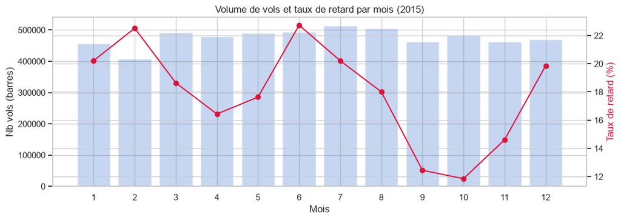

```python
month_stats = (df.groupby("MONTH", observed=True)
                 .agg(n_vols=("IS_DELAYED", "size"),
                      taux_retard=("IS_DELAYED", "mean"),
                      retard_moy_min=("ARRIVAL_DELAY", "mean"))
                 .reset_index())
month_stats["taux_retard"] *= 100
print(month_stats.round(2).to_string(index=False))

fig, ax1 = plt.subplots(figsize=(11, 4))
ax1.bar(month_stats["MONTH"], month_stats["n_vols"], alpha=0.3, label="Nb vols")
ax1.set_xlabel("Mois"); ax1.set_ylabel("Nb vols (barres)")
ax2 = ax1.twinx()
ax2.plot(month_stats["MONTH"], month_stats["taux_retard"], "o-",
         color="crimson", label="Taux de retard (%)")
ax2.set_ylabel("Taux de retard (%)", color="crimson")
ax1.set_xticks(range(1, 13))
plt.title("Volume de vols et taux de retard par mois (2015)")
fig.tight_layout()
plt.show()
```

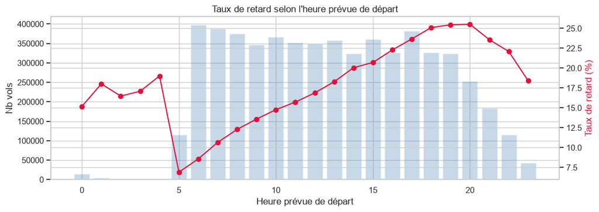

```python
hour_stats = (df.groupby("SCHEDULED_DEP_HOUR", observed=True)
                .agg(n_vols=("IS_DELAYED", "size"),
                     taux_retard=("IS_DELAYED", "mean"))
                .reset_index())
hour_stats["taux_retard"] *= 100

fig, ax1 = plt.subplots(figsize=(11, 4))
ax1.bar(hour_stats["SCHEDULED_DEP_HOUR"], hour_stats["n_vols"],
        alpha=0.3, color="steelblue", label="Nb vols")
ax1.set_xlabel("Heure prévue de départ"); ax1.set_ylabel("Nb vols")
ax2 = ax1.twinx()
ax2.plot(hour_stats["SCHEDULED_DEP_HOUR"], hour_stats["taux_retard"],
         "o-", color="crimson")
ax2.set_ylabel("Taux de retard (%)", color="crimson")
plt.title("Taux de retard selon l'heure prévue de départ")
fig.tight_layout()
plt.show()
```

```
AIRLINE                 AIRLINE_NAME  n_vols  taux_retard  retard_moy_min
     NK             Spirit Air Lines  115193       28.790          14.470
     F9       Frontier Airlines Inc.   90090       25.360          12.500
     B6              JetBlue Airways  262042       21.850           6.680
     MQ American Eagle Airlines Inc.  278791       21.030           6.460
     UA        United Air Lines Inc.  507762       19.950           5.430
     EV  Atlantic Southeast Airlines  554752       18.990           6.590
     VX               Virgin America   61248       18.530           4.740
     WN       Southwest Airlines Co. 1242403       18.300           4.370
     OO        Skywest Airlines Inc.  576814       18.000           5.850
     US              US Airways Inc.  194223       17.980           3.710
     AA       American Airlines Inc.  712935       17.570           3.450
     DL         Delta Air Lines Inc.  870275       13.000           0.190
     AS         Alaska Airlines Inc.  171439       12.340          -0.980
     HA       Hawaiian Airlines Inc.   76041       10.530           2.020
```

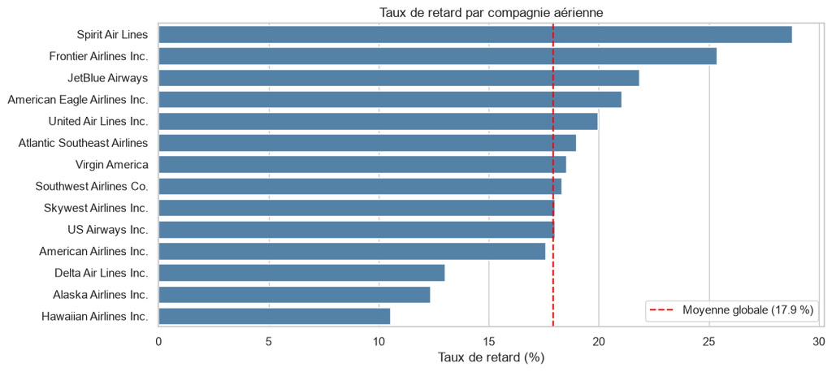

```python
# Jointure avec les noms de compagnies pour lisibilité
airlines_ref = (pd.read_csv(DATA_DIR / "airlines.csv")
                  .rename(columns={"AIRLINE": "AIRLINE_NAME"}))
airline_stats = (df.groupby("AIRLINE", observed=True)
                   .agg(n_vols=("IS_DELAYED", "size"),
                        taux_retard=("IS_DELAYED", "mean"),
                        retard_moy_min=("ARRIVAL_DELAY", "mean"))
                   .reset_index()
                   .merge(airlines_ref, left_on="AIRLINE", right_on="IATA_CODE")
                   .drop(columns=["IATA_CODE"]))
airline_stats["taux_retard"] *= 100
airline_stats = airline_stats.sort_values("taux_retard", ascending=False)
print(airline_stats[["AIRLINE", "AIRLINE_NAME", "n_vols",
                      "taux_retard", "retard_moy_min"]]
      .round(2).to_string(index=False))

fig, ax = plt.subplots(figsize=(11, 5))
sns.barplot(data=airline_stats, y="AIRLINE_NAME", x="taux_retard",
            color="steelblue", ax=ax)
ax.axvline(rate * 100, ls="--", color="red", label=f"Moyenne globale ({rate*100:.1f} %)")
ax.set_xlabel("Taux de retard (%)"); ax.set_ylabel(""); ax.legend()
plt.title("Taux de retard par compagnie aérienne")
plt.tight_layout(); plt.show()
```

```
=== 10 aéroports les PLUS retardés (≥ 10k vols) ===
ORIGIN_AIRPORT  n_vols  taux_retard  retard_moy_min
           ORD  276554       23.380           8.600
           LGA   94834       23.250           5.630
           MIA   68301       22.370           7.040
           BWI   84329       21.740           7.250
           DEN  193402       21.610           7.190
           DAL   58672       21.520           7.990
           JFK   91663       21.410           3.610
           MDW   78685       21.160           6.050
           PHL   64751       21.110           4.390
           PBI   22134       21.090           7.940

=== 10 aéroports les MOINS retardés (≥ 10k vols) ===
ORIGIN_AIRPORT  n_vols  taux_retard  retard_moy_min
         10397   32509        8.640          -4.220
           LIH   10487        9.100          -1.010
         13487   10552        9.420          -3.090
           KOA   11052        9.880          -0.240
           HNL   42946       10.100           0.800
         10721   10091       11.600          -1.730
         11292   18077       11.810          -1.250
           ANC   15818       11.830          -0.380
         14747   10361       12.130          -1.620
           OGG   20477       12.450           1.070
```

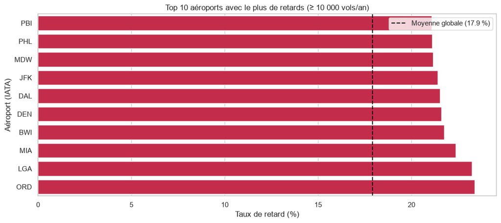

```python
MIN_FLIGHTS = 10_000  # seuil pour éviter les petits aéroports avec stats bruyantes
airport_stats = (df.groupby("ORIGIN_AIRPORT", observed=True)
                   .agg(n_vols=("IS_DELAYED", "size"),
                        taux_retard=("IS_DELAYED", "mean"),
                        retard_moy_min=("ARRIVAL_DELAY", "mean"))
                   .reset_index()
                   .query("n_vols >= @MIN_FLIGHTS"))
airport_stats["taux_retard"] *= 100

top10_worst = airport_stats.sort_values("taux_retard", ascending=False).head(10)
top10_best  = airport_stats.sort_values("taux_retard", ascending=True).head(10)
print("=== 10 aéroports les PLUS retardés (≥ 10k vols) ===")
print(top10_worst.round(2).to_string(index=False))
print("\n=== 10 aéroports les MOINS retardés (≥ 10k vols) ===")
print(top10_best.round(2).to_string(index=False))

fig, ax = plt.subplots(figsize=(11, 5))
sns.barplot(data=top10_worst.sort_values("taux_retard"),
            y="ORIGIN_AIRPORT", x="taux_retard", color="crimson", ax=ax)
ax.axvline(rate * 100, ls="--", color="black",
           label=f"Moyenne globale ({rate*100:.1f} %)")
ax.set_xlabel("Taux de retard (%)"); ax.set_ylabel("Aéroport (IATA)")
ax.legend()
plt.title("Top 10 aéroports avec le plus de retards (≥ 10 000 vols/an)")
plt.tight_layout(); plt.show()
```